# Forex Forecasting with MCMC

[Dorsa M. Arezooji](https://Dorsa-Arezooji.github.io)

## 0. Loading the required packages

```r
library(bsts)
library(ggplot2)
library(scales)
library(forecast)
```

## 1. Loading the data and creating the dataframe

`data.EURUSD = read.csv('EURUSD-2000-2020-15m.csv')` or `data.USDCAD = read.csv('USDCAD-2000-2020-15m.csv')`

#### *Note*

- If you use `n * train_test_split` instead of `n_train`, this will add extra identical rows like 2.1 4.1 in the training df!

```r
setwd('/home/dorsa/Desktop/projects/ForexMCMC')
set.seed(2020)
```

## 2. Functions

##### 2.1. `load_split()`

- This function loads and preprocesses the dataset by storing the data in a dataframe, formatting the column values, and then splits it into the training and testing dataframes.
- If your dataset has smaller time-frames (hour, minute, second), use `as.POSIXct()` instead of `as.Date()` with a correct format:

  01 Jan 2020 - 00:00:00 $\longrightarrow$ `as.POSIXct(data$TimeStamp, format = "%d %b %Y - %H:%M:%S")`
- `n_skip = 1` skips the first row of the dataset by default (assuming the first row contains headers). However, if you are using a large dataset (specially if you have smaller candles), R might crash in the sampling process. So it might be a good idea to skip a number of rows to reduce the data to the more recent points in time .

##### 2.2. `resDF()`

- This function stores the actual values, the predictions, and the points in time in a dataframe.

##### 2.3. `resviz()`

- This function uses the dataframe created by `resDF()` to plot the predictions and the actual values.

##### 2.4. `Accuracy()`

- This function calculates the accuracy of predictions using MAPE (Mean Absolute Percentage Error).

```r
load_split = function(data_csv, n_skip = 1, train_test_split, print_df = FALSE){
  data = read.csv(data_csv, skip = n_skip, header = FALSE, col.names = c('TimeStamp', 'Rate'))
  df = data.frame(as.Date(data$TimeStamp, format = "%d %b %Y"), as.numeric(data$Rate))
  names(df) = c('TimeStamp', 'Rate')
  n = nrow(df)
  n_train = floor(n * train_test_split)
  n_test = n - n_train
  df.train = df[1:n_train,]
  df.test = df[-(1:n_train),]
  rownames(df.test) = 1:nrow(df.test)
  l = list(df, df.train, df.test, n_train, n_test)
  if (print_df == TRUE){
    print('train df: ', quote = FALSE)
    print(df.train)
    print('test df: ', quote = FALSE)
    print(df.test)
  }
  return(l)
}

resDF = function(pred, actual){
  res = unlist(c(pred["original.series"], pred["mean"]))
  interval_L = unlist(c(rep(NA, n_train), pred[["interval"]][1,]))
  interval_U = unlist(c(rep(NA, n_train), pred[["interval"]][2,]))
  results = data.frame(actual[[1]], actual[[2]], res, interval_L, interval_U)
  names(results) = c('DateTime', 'Actual', 'Prediction', 'L', 'U')
  return(results)
}

resviz = function(results, title = ''){
  ggplot(results, aes(x = DateTime)) +
  theme_bw() + theme(legend.title = element_blank(), plot.title = element_text(hjust = 0.5), legend.position = "bottom") + labs(title = title, x = 'Time', y = 'Rate') +
  geom_line(aes(y = Actual, color = 'Actual')) +
  geom_line(aes(y = Prediction, color = 'Prediction'), linetype = 5) +
  geom_ribbon(aes(ymin = L, ymax = U), fill = 'grey', alpha = 0.3) +
  geom_vline(xintercept = results[n_train, 1], linetype = 4, color = 'blue', alpha = 0.3 )
}

Accuracy = function(test, pred){
accuracy = 100 - mean(abs(test[['Rate']] - pred[['mean']])/test[['Rate']]) * 100
return(accuracy)
}
```

## 3. Defining the model

```r
df_list = load_split('GBPCHF_daily_2016_2020.csv', train_test_split = 0.6, print_df = TRUE)
```

```
[1] train df:
```

|  | TimeStamp | Rate |
| --- | --- | --- |
| 1 | 2016-01-01 | 1.475748 |
| 2 | 2016-01-02 | 1.475922 |
| 3 | 2016-01-03 | 1.475922 |
| 4 | 2016-01-04 | 1.475922 |
| 5 | 2016-01-05 | 1.475516 |
| 6 | 2016-01-06 | 1.481145 |
| 7 | 2016-01-07 | 1.474565 |
| 8 | 2016-01-08 | 1.460866 |
| 9 | 2016-01-09 | 1.445893 |
| 10 | 2016-01-10 | 1.444586 |

[output cut: 860 more lines]

```
[1] test df:
```

|  | TimeStamp | Rate |
| --- | --- | --- |
| 1 | 2018-05-27 | 1.317211 |
| 2 | 2018-05-28 | 1.322311 |
| 3 | 2018-05-29 | 1.314044 |
| 4 | 2018-05-30 | 1.313438 |
| 5 | 2018-05-31 | 1.308332 |
| 6 | 2018-06-01 | 1.318737 |
| 7 | 2018-06-02 | 1.319001 |
| 8 | 2018-06-03 | 1.318994 |
| 9 | 2018-06-04 | 1.315664 |
| 10 | 2018-06-05 | 1.317412 |

[output cut: 570 more lines]

```r
df = df_list[[1]]
df.train = df_list[[2]]
df.test = df_list[[3]]
n_train = df_list[[4]]
n_test = df_list[[5]]
```

### 3.1. Local linear trend

```r
ss_1 = AddLocalLinearTrend(list(), df.train[[2]])
model_1 = bsts(df.train[[2]], state.specification = ss_1, niter = 2000, seed = 2020)
```

```
=-=-=-=-= Iteration 0 Sun Sep 13 22:09:56 2020 =-=-=-=-=
=-=-=-=-= Iteration 200 Sun Sep 13 22:09:57 2020 =-=-=-=-=
=-=-=-=-= Iteration 400 Sun Sep 13 22:09:57 2020 =-=-=-=-=
=-=-=-=-= Iteration 600 Sun Sep 13 22:09:58 2020 =-=-=-=-=
=-=-=-=-= Iteration 800 Sun Sep 13 22:09:59 2020 =-=-=-=-=
=-=-=-=-= Iteration 1000 Sun Sep 13 22:10:00 2020 =-=-=-=-=
=-=-=-=-= Iteration 1200 Sun Sep 13 22:10:01 2020 =-=-=-=-=
=-=-=-=-= Iteration 1400 Sun Sep 13 22:10:02 2020 =-=-=-=-=
=-=-=-=-= Iteration 1600 Sun Sep 13 22:10:02 2020 =-=-=-=-=
=-=-=-=-= Iteration 1800 Sun Sep 13 22:10:03 2020 =-=-=-=-=
```

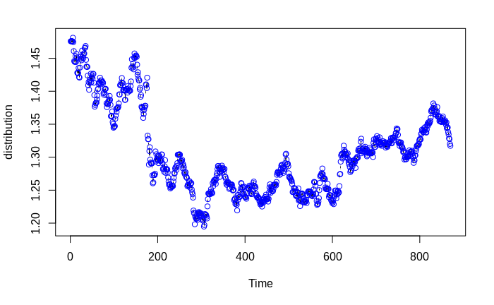

```r
plot(model_1)
```

#### Prediction using `model_1`

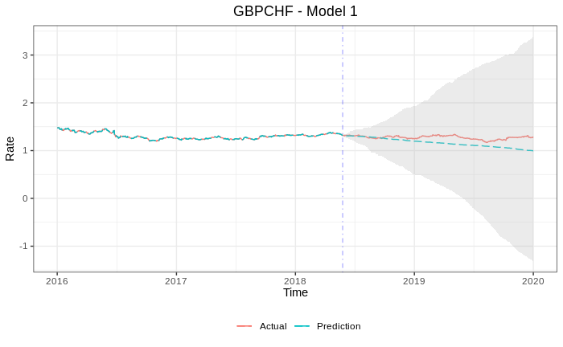

```r
pred_model_1 = predict(model_1, horizon = n_test, burn = SuggestBurn(0.1, model_1))
res_model_1 = resDF(pred_model_1, df)
resviz(res_model_1, title = 'GBPCHF - Model 1')
```

```r
print(Accuracy(df.test, pred_model_1))
```

```
[1] 91.17639
```

### 3.2. Local linear trend + Seasonal(52x7)

```r
ss_2 = AddLocalLinearTrend(list(), df.train[[2]])
ss_2 = AddSeasonal(ss_2, df.train[[2]], nseasons = 52 , season.duration = 7)
model_2 = bsts(df.train[[2]], state.specification = ss_2, niter = 2000, seed = 2020)
```

```
=-=-=-=-= Iteration 0 Sun Sep 13 22:17:06 2020 =-=-=-=-=
=-=-=-=-= Iteration 200 Sun Sep 13 22:17:15 2020 =-=-=-=-=
=-=-=-=-= Iteration 400 Sun Sep 13 22:17:23 2020 =-=-=-=-=
=-=-=-=-= Iteration 600 Sun Sep 13 22:17:32 2020 =-=-=-=-=
=-=-=-=-= Iteration 800 Sun Sep 13 22:17:40 2020 =-=-=-=-=
=-=-=-=-= Iteration 1000 Sun Sep 13 22:17:49 2020 =-=-=-=-=
=-=-=-=-= Iteration 1200 Sun Sep 13 22:17:57 2020 =-=-=-=-=
=-=-=-=-= Iteration 1400 Sun Sep 13 22:18:06 2020 =-=-=-=-=
=-=-=-=-= Iteration 1600 Sun Sep 13 22:18:14 2020 =-=-=-=-=
=-=-=-=-= Iteration 1800 Sun Sep 13 22:18:23 2020 =-=-=-=-=
```

#### Prediction using `model_2`

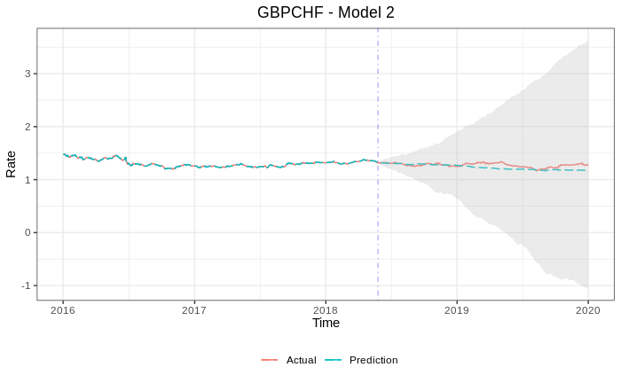

```r
pred_model_2 = predict(model_2, horizon = n_test, burn = SuggestBurn(0.1, model_2))
res_model_2 = resDF(pred_model_2, df)
resviz(res_model_2, title = 'GBPCHF - Model 2')
```

```r
print(Accuracy(df.test, pred_model_2))
```

```
[1] 96.26381
```

### 3.3. Local linear trend + Seasonal(52x7) + Seasonal(12x30)

```r
ss_3 = AddLocalLinearTrend(list(), df.train[[2]])
ss_3 = AddSeasonal(ss_3, df.train[[2]], nseasons = 52 , season.duration = 7)
ss_3 = AddSeasonal(ss_3, df.train[[2]], nseasons = 12, season.duration = 30)
model_3 = bsts(df.train[[2]], state.specification = ss_3, niter = 2000, seed = 2020)
```

```
=-=-=-=-= Iteration 0 Sun Sep 13 22:32:20 2020 =-=-=-=-=
=-=-=-=-= Iteration 200 Sun Sep 13 22:32:33 2020 =-=-=-=-=
=-=-=-=-= Iteration 400 Sun Sep 13 22:32:45 2020 =-=-=-=-=
=-=-=-=-= Iteration 600 Sun Sep 13 22:32:59 2020 =-=-=-=-=
=-=-=-=-= Iteration 800 Sun Sep 13 22:33:13 2020 =-=-=-=-=
=-=-=-=-= Iteration 1000 Sun Sep 13 22:33:28 2020 =-=-=-=-=
=-=-=-=-= Iteration 1200 Sun Sep 13 22:33:41 2020 =-=-=-=-=
=-=-=-=-= Iteration 1400 Sun Sep 13 22:33:59 2020 =-=-=-=-=
=-=-=-=-= Iteration 1600 Sun Sep 13 22:34:13 2020 =-=-=-=-=
=-=-=-=-= Iteration 1800 Sun Sep 13 22:34:26 2020 =-=-=-=-=
```

#### Prediction using `model_3`

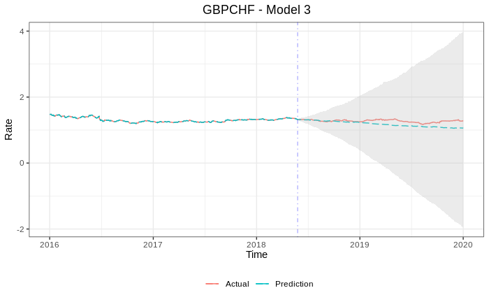

```r
pred_model_3 = predict(model_3, horizon = n_test, burn = SuggestBurn(0.1, model_3))
res_model_3 = resDF(pred_model_3, df)
resviz(res_model_3, title = 'GBPCHF - Model 3')
```

```r
print(Accuracy(df.test, pred_model_3))
```

```
[1] 92.5623
```

### 3.4. Local linear trend + Trig

```r
ss_4 = AddLocalLinearTrend(list(), df.train[[2]])
ss_4 = AddTrig(ss_4, df.train[[2]], period = 365, frequencies = c(1, 2, 4, 12))
model_4 = bsts(df.train[[2]], state.specification = ss_4, niter = 2000, seed = 2020)
```

```
=-=-=-=-= Iteration 0 Sun Sep 13 22:45:27 2020 =-=-=-=-=
=-=-=-=-= Iteration 200 Sun Sep 13 22:45:32 2020 =-=-=-=-=
=-=-=-=-= Iteration 400 Sun Sep 13 22:45:37 2020 =-=-=-=-=
=-=-=-=-= Iteration 600 Sun Sep 13 22:45:42 2020 =-=-=-=-=
=-=-=-=-= Iteration 800 Sun Sep 13 22:45:47 2020 =-=-=-=-=
=-=-=-=-= Iteration 1000 Sun Sep 13 22:46:02 2020 =-=-=-=-=
=-=-=-=-= Iteration 1200 Sun Sep 13 22:46:07 2020 =-=-=-=-=
=-=-=-=-= Iteration 1400 Sun Sep 13 22:46:12 2020 =-=-=-=-=
=-=-=-=-= Iteration 1600 Sun Sep 13 22:46:17 2020 =-=-=-=-=
=-=-=-=-= Iteration 1800 Sun Sep 13 22:46:23 2020 =-=-=-=-=
```

#### Prediction using `model_4`

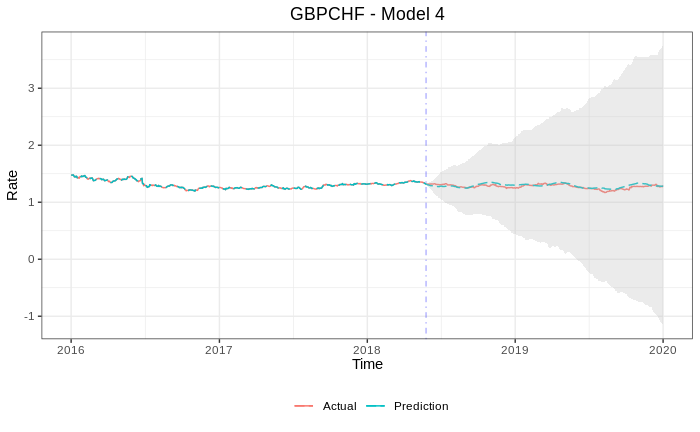

```r
pred_model_4 = predict(model_4, horizon = n_test, burn = SuggestBurn(0.1, model_4))
res_model_4 = resDF(pred_model_5, df)
resviz(res_model_4, title = 'GBPCHF - Model 4')
```

```r
print(Accuracy(df.test, pred_model_4))
```

```
[1] 98.28326
```

## 4. Comparison of models

### 4.1. In fitting the training data

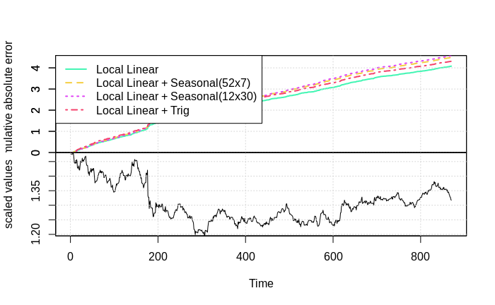

```r
model.list = list('Local Linear' = model_1, 'Local Linear + Seasonal(52x7)' = model_2, 'Local Linear + Seasonal(12x30)' = model_3, 'Local Linear + Trig' = model_4)
CompareBstsModels(model.list, burn = SuggestBurn(.1, model.list[[1]]), filename = "", colors = c('#42f5b3', '#f5ce42', '#e042f5', '#f5426c'), lwd = 2, xlab = "Time", main = "", grid = TRUE, cutpoint = NULL)
```

### 4.2. In predicting the test data

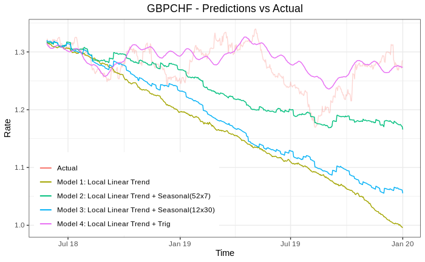

```r
ggplot(df.test, aes(x = TimeStamp)) +
theme_bw() + theme(legend.title = element_blank(), plot.title = element_text(hjust = 0.5), legend.position = c(0.25, 0.2), legend.direction = "vertical") + labs(title = 'GBPCHF - Predictions vs Actual', x = 'Time', y = 'Rate') + scale_x_date(date_labels = "%b %y") +
geom_line(aes(y = Rate, color = 'Actual'), alpha = 0.3) +
geom_line(aes(y = pred_model_1[['mean']], color = 'Model 1: Local Linear Trend')) +
geom_line(aes(y = pred_model_2[['mean']], color = 'Model 2: Local Linear Trend + Seasonal(52x7)')) +
geom_line(aes(y = pred_model_3[['mean']], color = 'Model 3: Local Linear Trend + Seasonal(12x30)')) +
geom_line(aes(y = pred_model_4[['mean']], color = 'Model 4: Local Linear Trend + Trig'))
```

## 5. Testing the model on another pair

```r
df_list_EURGBP = load_split('EURGBP_daily_2016_2020.csv', train_test_split = 0.6)
df_EURGBP = df_list_EURGBP[[1]]
df.train_EURGBP = df_list_EURGBP[[2]]
df.test_EURGBP = df_list_EURGBP[[3]]

ss = AddLocalLinearTrend(list(), df.train_EURGBP[[2]])
ss = AddTrig(ss, df.train_EURGBP[[2]], period = 365, frequencies = c(1, 2, 4, 12))
model_4_EURGBP = bsts(df.train_EURGBP[[2]], state.specification = ss, niter = 2000, seed = 2020)
```

```
=-=-=-=-= Iteration 0 Sun Sep 13 23:04:02 2020 =-=-=-=-=
=-=-=-=-= Iteration 200 Sun Sep 13 23:04:07 2020 =-=-=-=-=
=-=-=-=-= Iteration 400 Sun Sep 13 23:04:12 2020 =-=-=-=-=
=-=-=-=-= Iteration 600 Sun Sep 13 23:04:17 2020 =-=-=-=-=
=-=-=-=-= Iteration 800 Sun Sep 13 23:04:22 2020 =-=-=-=-=
=-=-=-=-= Iteration 1000 Sun Sep 13 23:04:27 2020 =-=-=-=-=
=-=-=-=-= Iteration 1200 Sun Sep 13 23:04:32 2020 =-=-=-=-=
=-=-=-=-= Iteration 1400 Sun Sep 13 23:04:37 2020 =-=-=-=-=
=-=-=-=-= Iteration 1600 Sun Sep 13 23:04:41 2020 =-=-=-=-=
=-=-=-=-= Iteration 1800 Sun Sep 13 23:04:46 2020 =-=-=-=-=
```

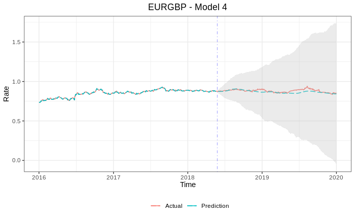

```r
pred_model_4_EURGBP = predict(model_4_EURGBP, horizon = n_test, burn = SuggestBurn(0.1, model_4_EURGBP))
res_model_4_EURGBP = resDF(pred_model_4_EURGBP, df_EURGBP)
resviz(res_model, title = 'EURGBP - Model 4')
```

```r
print(Accuracy(df.test_EURGBP, pred_model_4_EURGBP))
```

```
[1] 97.22846
```

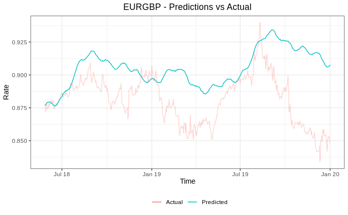

```r
ggplot(df.test_EURGBP, aes(x = TimeStamp)) +
theme_bw() + theme(legend.title = element_blank(), plot.title = element_text(hjust = 0.5), legend.position = 'bottom') + labs(title = 'EURGBP - Predictions vs Actual', x = 'Time', y = 'Rate') + scale_x_date(date_labels = "%b %y") +
geom_line(aes(y = Rate, color = 'Actual'), alpha = 0.3) +
geom_line(aes(y = pred_model_4_EURGBP[['mean']], color = 'Predicted'))
```

## 6. Non-Bayesian models

### 6.1. ARIMA

```r
model_ARIMA = auto.arima(df.train[[2]])
summary(model_ARIMA)
```

```
Series: df.train[[2]]
ARIMA(2,1,4)

Coefficients:
          ar1      ar2     ma1     ma2     ma3     ma4
      -1.2816  -0.8533  1.2501  0.8682  0.1313  0.1045
s.e.   0.1135   0.1626  0.1134  0.1645  0.0691  0.0388

sigma^2 estimated as 5.097e-05:  log likelihood=3064.62
AIC=-6115.24   AICc=-6115.11   BIC=-6081.87

Training set error measures:
                        ME        RMSE         MAE         MPE      MAPE     MASE          ACF1
Training set -0.0001695679 0.007110436 0.004639592 -0.01350554 0.3532572 1.021481 -0.0002545359
```

```r
pred_model_ARIMA = data.frame(forecast(model_ARIMA, h = n_test))
print(100 - mean(abs(df.test[['Rate']] - pred_model_ARIMA[[1]]/df.test[['Rate']]) * 100))
```

```
[1] 75.66613
```

### 6.2. Comparison

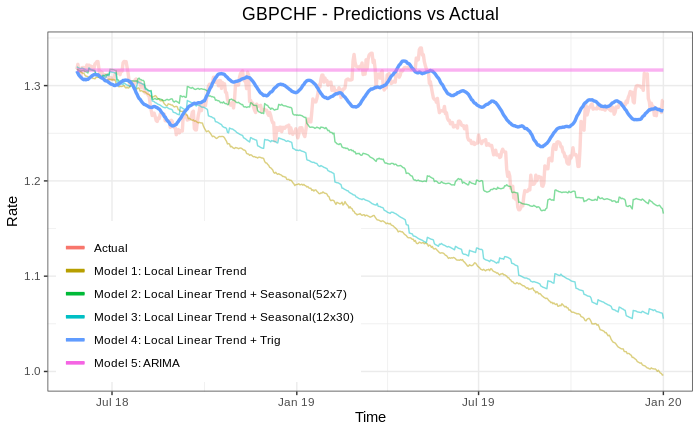

```r
ggplot(df.test, aes(x = TimeStamp)) +
theme_bw() + theme(legend.title = element_blank(), plot.title = element_text(hjust = 0.5), legend.position = c(0.25, 0.25), legend.direction = "vertical") + labs(title = 'GBPCHF - Predictions vs Actual', x = 'Time', y = 'Rate') + scale_x_date(date_labels = "%b %y") +
geom_line(aes(y = Rate, color = 'Actual'), alpha = 0.3, lwd = 1.2) +
geom_line(aes(y = pred_model_1[['mean']], color = 'Model 1: Local Linear Trend'), alpha = 0.5) +
geom_line(aes(y = pred_model_2[['mean']], color = 'Model 2: Local Linear Trend + Seasonal(52x7)'), alpha = 0.5) +
geom_line(aes(y = pred_model_3[['mean']], color = 'Model 3: Local Linear Trend + Seasonal(12x30)'), alpha = 0.5) +
geom_line(aes(y = pred_model_4[['mean']], color = 'Model 4: Local Linear Trend + Trig'), lwd = 1.2) +
geom_line(aes(y = pred_model_ARIMA[[1]], color = 'Model 5: ARIMA'), alpha = 0.5, lwd = 1.2)
```